# Behavioral Science and Marketing Data Analysis Tasks

2024-02-18

```r
# loading required packages
library(tidyverse) # for data wrangling
library(readxl) # to read excel files
library(afex) # to run ANOVA
library(emmeans) # to conduct pairwise t-tests after ANOVA

# setting ggplot theme
theme_set(theme_minimal(base_size = 15))
```

# Task 1

```r
# reading the raw dataset from the excel file
raw_data <- read_excel("Data - Fall 2023.xlsx",
                       sheet = "Data")

# excluding the incomplete or unfinished responses from the dataset
data_clean1 <- raw_data |>
  filter(Progress == 100,
         passedattn == "yes",
         consent == "AGREE",
         age < 100) |>
  distinct() # removing duplicate rows

# selecting only the necessary columns for further analyses
data_clean2 <- data_clean1 |>
  select(ResponseId,
         feelings_youalone : feelings_youaloneforgiven,
         outcome_binary1, initiator_type)
```

## Do people care about getting a return apology?

```r
# making a data table with summary statistics for each group
summary_data <- data_clean2 |>
  select(feelings_youalone : feelings_youaloneforgiven) |>
  summarize(across(everything(), list(n = ~n(),
                                      mean = ~mean(., na.rm = TRUE),
                                      sd = ~sd(., na.rm = TRUE))))

# conducting paired samples t-test to assess whether people care about a return apology
care_test <- t.test(data_clean2$feelings_bothyoufirst, data_clean2$feelings_youalone,
                    paired = TRUE)

# extracting t-test results
care_t = round(care_test$statistic, 3)
care_df = care_test$parameter
care_p = care_test$p.value
care_prob = ifelse(care_p < .001, "<", "=")
care_p = ifelse(care_p < .001, .001, round(care_p, 3))
care_ci = round(care_test$conf.int, 2)

# extracting mean and sd
youalone_mean = round(summary_data$feelings_youalone_mean, 2)
youalone_sd = round(summary_data$feelings_youalone_sd, 2)
bothyoufirst_mean = round(summary_data$feelings_bothyoufirst_mean, 2)
bothyoufirst_sd = round(summary_data$feelings_bothyoufirst_sd, 2)
```

The subjects cared about getting a return apology after they apologized first. Their average self-reported feeling when they received a return apology after they apologized first was positive, while their reported feeling was negative on average when they did not receive a return apology.

The subjects cared about getting a return apology after they apologized first. The repeated measures t-test demonstrated a statistically significant difference in the subjects’ feelings when they apologized first but did not receive an apology in return (M = -18.36, SD = 12.03) and when they apologized first and received an apology in return (M = 7.84, SD = 14.45); t(44) = 12.625, p < 0.001.

## Does the effect vary as a function of “initiator type”?

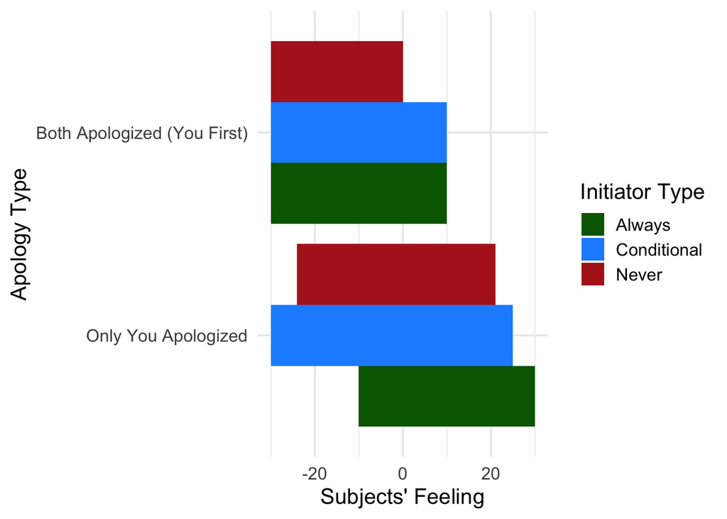

Figure 1: Effects of initiator type and apology type on subjects’ feelings.

```r
# converting the cleaned dataset to long format
data_apology <- data_clean2 |>
  pivot_longer(cols = "feelings_youalone":"feelings_youaloneforgiven",
               names_to = "apology_type",
               values_to = "response")

# filtering data for 2 X 2 ANOVA
filtered_data <- data_apology |>
  filter(apology_type %in% c("feelings_bothyoufirst", "feelings_youalone"))

# running a 2 x 2 ANOVA to assess whether the effect varies as a function of initiator type
twoway_anova <- aov_ez(id = "ResponseId", between = "initiator_type",
                       within = "apology_type", dv = "response",
                       es = "pes", data = filtered_data)
# summary(twoway_anova)

# extracting ANOVA results
anova_results <- broom::tidy(twoway_anova$anova_table)

# creating a grouped bar chart to illustrate ANOVA findings
anova_barplot <- ggplot(filtered_data,
                        aes(x = apology_type, y = response,
                            fill = initiator_type)) +
  geom_bar(stat = "identity", position = position_dodge()) +
  labs(x = "Apology Type",
       y = "Subjects' Feeling",
       fill = "Initiator Type") +
  scale_x_discrete(labels = c("Only You Apologized", "Both Apologized (You First)")) +
  scale_fill_manual(values = c("darkgreen", "dodgerblue", "firebrick"),
    labels = c("Always", "Conditional", "Never")) +
  coord_flip()

print(anova_barplot)
```

A two-way ANOVA was performed to assess the effects of initiator type and apology type on the subjects’ feelings. The results indicated a significant main effect for initiator type, F(2, 42) = 4.22, p = .021, suggesting that subjects’ feelings depended on whether they recognized themselves as always initiators, never initiators, or conditional initiators. Figure 1 presented the difference in subjects’ feeling as a function of initiator type and apology type.

The results also revealed a significant main effect for apology type, F(1, 42) = 139.12, p < .001. However, the interaction between initiator type and apology type was not significant, F(2, 42) = .65, p = .527, suggesting that the effect of initiator type on the subjects’ feelings did not significantly vary across the levels of apology type.

## Is return apology viewed as a form of forgiveness?

```r
# conducting paired samples t-test to assess whether people view return apology as a form of forgiveness
forgive_test <- t.test(data_clean2$feelings_youaloneforgiven, data_clean2$feelings_youalone,
                    paired = TRUE)

# extracting t-test results
forgive_t = round(forgive_test$statistic, 3)
forgive_df = forgive_test$parameter
forgive_p = forgive_test$p.value
forgive_prob = ifelse(forgive_p < .001, "<", "=")
forgive_p = ifelse(forgive_p < .001, .001, round(forgive_p, 3))
forgive_ci = round(forgive_test$conf.int, 2)

# extracting mean and sd
youaloneforgiven_mean = round(summary_data$feelings_youaloneforgiven_mean, 2)
youaloneforgiven_sd = round(summary_data$feelings_youaloneforgiven_sd, 2)
```

The subjects viewed the return apology as a form of forgiveness. The participants’ average feeling remained negative after receiving forgiveness in return for their apology, even though the average feeling was more negative when they did not receive any apology or forgiveness in return.

The repeated measures t-test demonstrated a statistically significant difference in the subjects’ feelings when they apologized first but did not receive an apology in return (M = -18.36, SD = 12.03) and when they apologized first but the other person only forgave them in return (M = -13.91, SD = 15.62); t(44) = 2.142, p = 0.038.

# Task 2

## Average Feeling

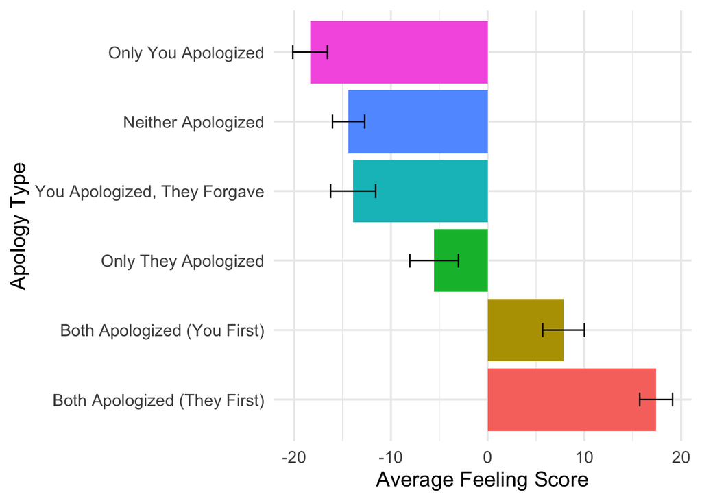

Figure 2: Average feeling score by apology type.

```r
# creating data table with average feelings and standard errors for six different scenarios and arranging them in descending order
apology_se <- data_apology |>
  group_by(apology_type) |>
  summarize(
    mean_feeling = mean(response, na.rm = TRUE),
    se = sd(response, na.rm = TRUE) / sqrt(n())
  ) |>
  arrange(desc(mean_feeling)) |>
  mutate(order = factor(apology_type, levels = apology_type))

# creating barplot of average feelings for six different scenarios
feelings_barplot <- ggplot(apology_se,
                           aes(x = order, y = mean_feeling,
                               fill = order)) +
  geom_bar(stat = "identity", position = position_dodge()) +
  geom_errorbar(aes(ymin = mean_feeling - se, ymax = mean_feeling + se),
                width = 0.2,
                position = position_dodge(0.9)) +
  coord_flip() +
  scale_x_discrete(labels = c("Both Apologized (They First)", "Both Apologized (You First)",
                              "Only They Apologized", "You Apologized, They Forgave",
                              "Neither Apologized", "Only You Apologized")) +
  labs(x = "Apology Type", y = "Average Feeling Score") +
  guides(fill = "none")

feelings_barplot
```

Figure 2 shows that a return apology has an effect on the participants’ feelings. The subjects experienced positive feelings only when they received an apology in return. In the four scenarios in which they did not receive a return apology, they had negative feelings.

## One-way ANOVA

```r
# conducting an one-way ANOVA
anova_feelings <- aov_ez(id = "ResponseId",
                         dv = "response",
                         within = "apology_type",
                         data = data_apology)
# summary(anova_feelings)

# pairwise t-tests comparing "feelings_youalone" to other five scenarios
pair_feelings <- emmeans(anova_feelings,
                         pairwise ~ apology_type,
                         adjust = "bonferroni")

# filtering only those comparisons made with "feelings_youalone"
feelings_stats <- broom::tidy(pair_feelings$contrasts)
youalone_results <- feelings_stats |>
  filter(str_detect(contrast, "feelings_youalone(?!forgiven)"))
```

The one-way repeated measures ANOVA demonstrated a significant main effect of apology type on the participants’ feelings, F(5, 220) = 54.726, p < .001, suggesting that different types of apologies affect subjects’ feelings.

## Proportion of subjects choosing different Outcome_binary1 options

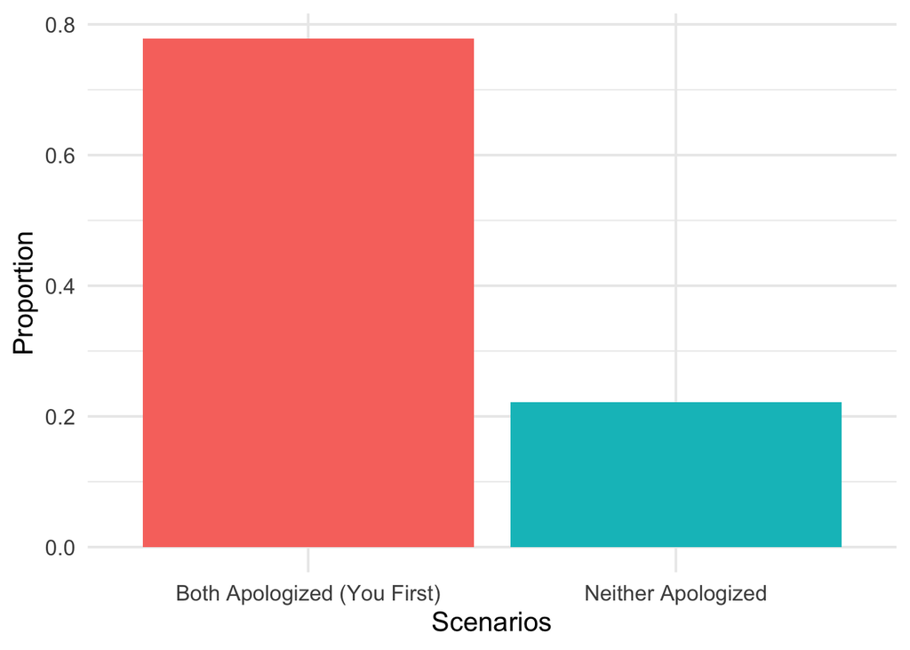

Figure 3: Proportion of people choosing different scenarios.

```r
# calculating the proportions of people choosing different options in outcome_binary1
proportions <- data_clean2 |>
  group_by(outcome_binary1) |>
  summarize(count = n()) |>
  mutate(outcome_proportion = count/ sum(count))

# creating a bar plot
barplot <- ggplot(proportions,
                  aes(x = outcome_binary1, y = outcome_proportion,
                      fill = outcome_binary1)) +
  geom_bar(stat = "identity") +
  scale_x_discrete(labels = c("Both Apologized (You First)",
                              "Neither Apologized")) +
  labs(x = "Scenarios", y = "Proportion") +
  guides(fill = "none")

print(barplot)
```

```r
# performing chi-square test
outcome_diff_test <- chisq.test(proportions$outcome_proportion)

# print(outcome_diff_test)
```

```r
# conducting paired samples t-test to assess whether people care about the order of receiving apology from others
apology_order <- t.test(data_clean2$feelings_boththemfirst, data_clean2$feelings_bothyoufirst,
                    paired = TRUE)
order_results <- broom::tidy(apology_order)
```